# Risk Factor Analysis

## Outcome Variable

**Outcome Variable:** haz

## Predictor Variables

**Intervention Variable:** single

**Adjustment Set:**

- arm
- W_mage
- meducyrs
- feducyrs
- W_mhtcm
- W_mwtkg
- W_mbmi
- delta_W_mage
- delta_meducyrs
- delta_feducyrs
- delta_W_mhtcm
- delta_W_mwtkg
- delta_W_mbmi

## Stratifying Variables

The analysis was stratified on these variable(s):

- agecat
- studyid
- country

## Data Summary

| agecat | studyid | country | single | n_cell | n |
| --- | --- | --- | --- | --- | --- |
| Birth | COHORTS | GUATEMALA | 0 | 719 | 767 |
| Birth | COHORTS | GUATEMALA | 1 | 48 | 767 |
| Birth | COHORTS | INDIA | 0 | 4771 | 4778 |
| Birth | COHORTS | INDIA | 1 | 7 | 4778 |
| Birth | COHORTS | PHILIPPINES | 0 | 2936 | 3010 |
| Birth | COHORTS | PHILIPPINES | 1 | 74 | 3010 |
| Birth | JiVitA-4 | BANGLADESH | 0 | 2814 | 2819 |
| Birth | JiVitA-4 | BANGLADESH | 1 | 5 | 2819 |
| Birth | MAL-ED | BANGLADESH | 0 | 231 | 231 |
| Birth | MAL-ED | BANGLADESH | 1 | 0 | 231 |
| Birth | MAL-ED | BRAZIL | 0 | 57 | 65 |
| Birth | MAL-ED | BRAZIL | 1 | 8 | 65 |
| Birth | MAL-ED | INDIA | 0 | 47 | 47 |
| Birth | MAL-ED | INDIA | 1 | 0 | 47 |
| Birth | MAL-ED | NEPAL | 0 | 27 | 27 |
| Birth | MAL-ED | NEPAL | 1 | 0 | 27 |
| Birth | MAL-ED | PERU | 0 | 209 | 233 |
| Birth | MAL-ED | PERU | 1 | 24 | 233 |
| Birth | MAL-ED | SOUTH AFRICA | 0 | 63 | 123 |
| Birth | MAL-ED | SOUTH AFRICA | 1 | 60 | 123 |
| Birth | MAL-ED | TANZANIA, UNITED REPUBLIC OF | 0 | 122 | 125 |
| Birth | MAL-ED | TANZANIA, UNITED REPUBLIC OF | 1 | 3 | 125 |
| Birth | PROBIT | BELARUS | 0 | 13351 | 13893 |
| Birth | PROBIT | BELARUS | 1 | 542 | 13893 |
| Birth | ZVITAMBO | ZIMBABWE | 0 | 12942 | 13817 |
| Birth | ZVITAMBO | ZIMBABWE | 1 | 875 | 13817 |
| 6 months | COHORTS | GUATEMALA | 0 | 826 | 893 |
| 6 months | COHORTS | GUATEMALA | 1 | 67 | 893 |
| 6 months | COHORTS | INDIA | 0 | 4962 | 4971 |
| 6 months | COHORTS | INDIA | 1 | 9 | 4971 |

[output cut: 54 more lines]

The following strata were considered:

- agecat: 24 months, studyid: COHORTS, country: GUATEMALA
- agecat: 24 months, studyid: COHORTS, country: INDIA
- agecat: 24 months, studyid: COHORTS, country: PHILIPPINES
- agecat: 24 months, studyid: JiVitA-4, country: BANGLADESH
- agecat: 24 months, studyid: MAL-ED, country: BANGLADESH
- agecat: 24 months, studyid: MAL-ED, country: BRAZIL
- agecat: 24 months, studyid: MAL-ED, country: INDIA
- agecat: 24 months, studyid: MAL-ED, country: NEPAL
- agecat: 24 months, studyid: MAL-ED, country: PERU
- agecat: 24 months, studyid: MAL-ED, country: SOUTH AFRICA
- agecat: 24 months, studyid: MAL-ED, country: TANZANIA, UNITED REPUBLIC OF
- agecat: 24 months, studyid: PROBIT, country: BELARUS
- agecat: 24 months, studyid: TanzaniaChild2, country: TANZANIA, UNITED REPUBLIC OF
- agecat: 24 months, studyid: ZVITAMBO, country: ZIMBABWE
- agecat: 6 months, studyid: COHORTS, country: GUATEMALA
- agecat: 6 months, studyid: COHORTS, country: INDIA
- agecat: 6 months, studyid: COHORTS, country: PHILIPPINES
- agecat: 6 months, studyid: Guatemala BSC, country: GUATEMALA
- agecat: 6 months, studyid: JiVitA-4, country: BANGLADESH
- agecat: 6 months, studyid: MAL-ED, country: BANGLADESH
- agecat: 6 months, studyid: MAL-ED, country: BRAZIL
- agecat: 6 months, studyid: MAL-ED, country: INDIA
- agecat: 6 months, studyid: MAL-ED, country: NEPAL
- agecat: 6 months, studyid: MAL-ED, country: PERU
- agecat: 6 months, studyid: MAL-ED, country: SOUTH AFRICA
- agecat: 6 months, studyid: MAL-ED, country: TANZANIA, UNITED REPUBLIC OF
- agecat: 6 months, studyid: PROBIT, country: BELARUS
- agecat: 6 months, studyid: TanzaniaChild2, country: TANZANIA, UNITED REPUBLIC OF
- agecat: 6 months, studyid: ZVITAMBO, country: ZIMBABWE
- agecat: Birth, studyid: COHORTS, country: GUATEMALA
- agecat: Birth, studyid: COHORTS, country: INDIA
- agecat: Birth, studyid: COHORTS, country: PHILIPPINES
- agecat: Birth, studyid: JiVitA-4, country: BANGLADESH
- agecat: Birth, studyid: MAL-ED, country: BANGLADESH
- agecat: Birth, studyid: MAL-ED, country: BRAZIL
- agecat: Birth, studyid: MAL-ED, country: INDIA
- agecat: Birth, studyid: MAL-ED, country: NEPAL
- agecat: Birth, studyid: MAL-ED, country: PERU
- agecat: Birth, studyid: MAL-ED, country: SOUTH AFRICA
- agecat: Birth, studyid: MAL-ED, country: TANZANIA, UNITED REPUBLIC OF
- agecat: Birth, studyid: PROBIT, country: BELARUS
- agecat: Birth, studyid: ZVITAMBO, country: ZIMBABWE

### Dropped Strata

Some strata were dropped due to rare outcomes:

- agecat: Birth, studyid: MAL-ED, country: BANGLADESH
- agecat: Birth, studyid: MAL-ED, country: INDIA
- agecat: Birth, studyid: MAL-ED, country: NEPAL
- agecat: Birth, studyid: MAL-ED, country: TANZANIA, UNITED REPUBLIC OF
- agecat: 6 months, studyid: MAL-ED, country: BANGLADESH
- agecat: 6 months, studyid: MAL-ED, country: INDIA
- agecat: 6 months, studyid: MAL-ED, country: NEPAL
- agecat: 24 months, studyid: MAL-ED, country: BANGLADESH
- agecat: 24 months, studyid: MAL-ED, country: INDIA
- agecat: 24 months, studyid: MAL-ED, country: NEPAL
- agecat: 24 months, studyid: TanzaniaChild2, country: TANZANIA, UNITED REPUBLIC OF

## Methods Detail

We’re interested in the causal parameters $E[Y_a]$ for all values of $a \in \mathcal{A}$. These parameters represent the mean outcome if, possibly contrary to fact, we intervened to set all units to have $A=a$. Under the randomization and positivity assumptions, these are identified by the statistical parameters $\psi_a=E_W[E_{Y|A,W}(Y|A=a,W)]$. In addition, we’re interested in the mean of $Y$, $E[Y]$ under no intervention (the observed mean). We will estimate these parameters by using SuperLearner to fit the relevant likelihood factors – $E_{Y|A,W}(Y|A=a,W)$ and $p(A=a|W)$, and then updating our likelihood fit using a joint TMLE.

For unadjusted analyses ($W=\{\}$), initial likelihoods were estimated using Lrnr_glm to estimate the simple $E(Y|A)$ and Lrnr_mean to estimate $p(A)$. For adjusted analyses, a small library containing Lrnr_glmnet, Lrnr_xgboost, and Lrnr_mean was used.

Having estimated these parameters, we will then use the delta method to estimate relative risks and attributable risks relative to a prespecified baseline level of $A$.

# Results Detail

## Results Plots

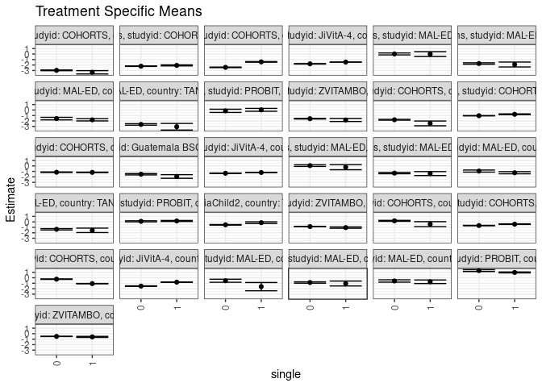

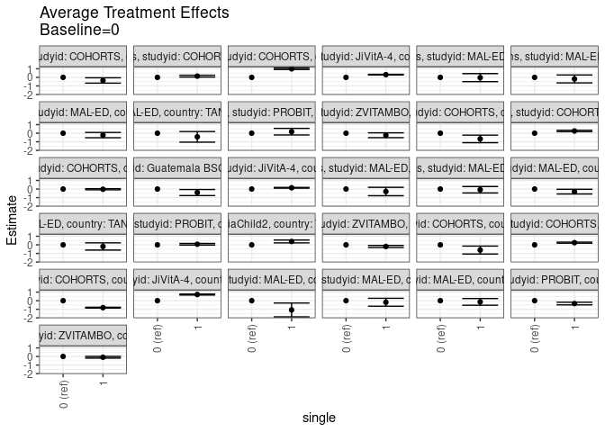

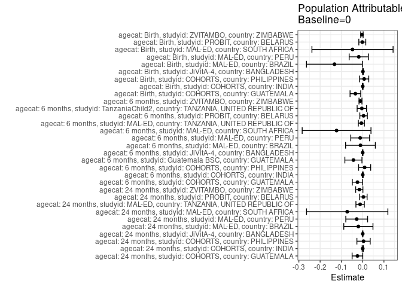

## Results Table

### Parameter: TSM

| agecat | studyid | country | intervention_level | baseline_level | estimate | ci_lower | ci_upper |
| --- | --- | --- | --- | --- | --- | --- | --- |
| Birth | COHORTS | GUATEMALA | 0 | NA | 0.1853430 | 0.0958461 | 0.2748400 |
| Birth | COHORTS | GUATEMALA | 1 | NA | -0.4197002 | -0.8727284 | 0.0333279 |
| Birth | COHORTS | INDIA | 0 | NA | -0.6778139 | -0.7115208 | -0.6441070 |
| Birth | COHORTS | INDIA | 1 | NA | -0.4242857 | -0.4784569 | -0.3701145 |
| Birth | COHORTS | PHILIPPINES | 0 | NA | -0.2536295 | -0.2992455 | -0.2080135 |
| Birth | COHORTS | PHILIPPINES | 1 | NA | -1.0668644 | -1.0915688 | -1.0421600 |
| Birth | JiVitA-4 | BANGLADESH | 0 | NA | -1.5248721 | -1.5752417 | -1.4745025 |
| Birth | JiVitA-4 | BANGLADESH | 1 | NA | -0.8080000 | -0.8384743 | -0.7775257 |
| Birth | MAL-ED | BRAZIL | 0 | NA | -0.5433333 | -0.8229128 | -0.2637539 |
| Birth | MAL-ED | BRAZIL | 1 | NA | -1.6212500 | -2.3756597 | -0.8668403 |
| Birth | MAL-ED | PERU | 0 | NA | -0.8644773 | -0.9854757 | -0.7434788 |
| Birth | MAL-ED | PERU | 1 | NA | -1.0475091 | -1.4951173 | -0.5999009 |
| Birth | MAL-ED | SOUTH AFRICA | 0 | NA | -0.5839387 | -0.7969125 | -0.3709649 |
| Birth | MAL-ED | SOUTH AFRICA | 1 | NA | -0.7251714 | -1.0524975 | -0.3978452 |
| Birth | PROBIT | BELARUS | 0 | NA | 1.3130936 | 1.1467522 | 1.4794351 |
| Birth | PROBIT | BELARUS | 1 | NA | 0.9765383 | 0.8883707 | 1.0647060 |
| Birth | ZVITAMBO | ZIMBABWE | 0 | NA | -0.4973134 | -0.5185319 | -0.4760950 |
| Birth | ZVITAMBO | ZIMBABWE | 1 | NA | -0.5845758 | -0.6797815 | -0.4893701 |
| 6 months | COHORTS | GUATEMALA | 0 | NA | -1.7844599 | -1.8572513 | -1.7116685 |
| 6 months | COHORTS | GUATEMALA | 1 | NA | -2.4492198 | -2.8822483 | -2.0161914 |
| 6 months | COHORTS | INDIA | 0 | NA | -1.0423478 | -1.0757913 | -1.0089044 |
| 6 months | COHORTS | INDIA | 1 | NA | -0.7833333 | -0.8545896 | -0.7120771 |
| 6 months | COHORTS | PHILIPPINES | 0 | NA | -1.1507568 | -1.2028734 | -1.0986402 |
| 6 months | COHORTS | PHILIPPINES | 1 | NA | -1.1749513 | -1.2168007 | -1.1331018 |
| 6 months | Guatemala BSC | GUATEMALA | 0 | NA | -1.5188991 | -1.6412772 | -1.3965210 |
| 6 months | Guatemala BSC | GUATEMALA | 1 | NA | -1.9276938 | -2.2597626 | -1.5956251 |
| 6 months | JiVitA-4 | BANGLADESH | 0 | NA | -1.3443862 | -1.3825869 | -1.3061854 |
| 6 months | JiVitA-4 | BANGLADESH | 1 | NA | -1.1993750 | -1.2225095 | -1.1762405 |
| 6 months | MAL-ED | BRAZIL | 0 | NA | 0.0579299 | -0.0924244 | 0.2082843 |
| 6 months | MAL-ED | BRAZIL | 1 | NA | -0.2320855 | -0.6969147 | 0.2327437 |
| 6 months | MAL-ED | PERU | 0 | NA | -1.3119676 | -1.4249870 | -1.1989482 |
| 6 months | MAL-ED | PERU | 1 | NA | -1.3960455 | -1.7534591 | -1.0386319 |
| 6 months | MAL-ED | SOUTH AFRICA | 0 | NA | -0.9406429 | -1.1322026 | -0.7490832 |
| 6 months | MAL-ED | SOUTH AFRICA | 1 | NA | -1.2451661 | -1.4407129 | -1.0496194 |
| 6 months | MAL-ED | TANZANIA, UNITED REPUBLIC OF | 0 | NA | -1.3626290 | -1.4879351 | -1.2373229 |
| 6 months | MAL-ED | TANZANIA, UNITED REPUBLIC OF | 1 | NA | -1.5514583 | -1.9539746 | -1.1489420 |
| 6 months | PROBIT | BELARUS | 0 | NA | 0.0936247 | -0.0029695 | 0.1902189 |
| 6 months | PROBIT | BELARUS | 1 | NA | 0.1647740 | 0.0719673 | 0.2575808 |
| 6 months | TanzaniaChild2 | TANZANIA, UNITED REPUBLIC OF | 0 | NA | -0.5418876 | -0.5966957 | -0.4870796 |
| 6 months | TanzaniaChild2 | TANZANIA, UNITED REPUBLIC OF | 1 | NA | -0.1479735 | -0.3050406 | 0.0090936 |
| 6 months | ZVITAMBO | ZIMBABWE | 0 | NA | -0.8574621 | -0.8838150 | -0.8311092 |
| 6 months | ZVITAMBO | ZIMBABWE | 1 | NA | -1.0486304 | -1.1684849 | -0.9287759 |
| 24 months | COHORTS | GUATEMALA | 0 | NA | -2.9715184 | -3.0422199 | -2.9008168 |
| 24 months | COHORTS | GUATEMALA | 1 | NA | -3.3304293 | -3.6342523 | -3.0266063 |
| 24 months | COHORTS | INDIA | 0 | NA | -2.2134909 | -2.2535699 | -2.1734120 |
| 24 months | COHORTS | INDIA | 1 | NA | -2.0688889 | -2.1675727 | -1.9702051 |
| 24 months | COHORTS | PHILIPPINES | 0 | NA | -2.4249523 | -2.4816399 | -2.3682648 |
| 24 months | COHORTS | PHILIPPINES | 1 | NA | -1.4290833 | -1.4856210 | -1.3725457 |
| 24 months | JiVitA-4 | BANGLADESH | 0 | NA | -1.7815365 | -1.8179487 | -1.7451244 |
| 24 months | JiVitA-4 | BANGLADESH | 1 | NA | -1.4650000 | -1.4755957 | -1.4544043 |
| 24 months | MAL-ED | BRAZIL | 0 | NA | 0.0262491 | -0.1523403 | 0.2048385 |
| 24 months | MAL-ED | BRAZIL | 1 | NA | -0.0028320 | -0.4391944 | 0.4335303 |
| 24 months | MAL-ED | PERU | 0 | NA | -1.7244689 | -1.8508903 | -1.5980474 |
| 24 months | MAL-ED | PERU | 1 | NA | -1.9059144 | -2.3516010 | -1.4602278 |
| 24 months | MAL-ED | SOUTH AFRICA | 0 | NA | -1.5724055 | -1.8042286 | -1.3405823 |
| 24 months | MAL-ED | SOUTH AFRICA | 1 | NA | -1.7939495 | -1.9966606 | -1.5912384 |
| 24 months | MAL-ED | TANZANIA, UNITED REPUBLIC OF | 0 | NA | -2.6336298 | -2.7712599 | -2.4959997 |
| 24 months | MAL-ED | TANZANIA, UNITED REPUBLIC OF | 1 | NA | -3.0591667 | -3.6621048 | -2.4562285 |
| 24 months | PROBIT | BELARUS | 0 | NA | -0.1477653 | -0.4392656 | 0.1437349 |
| 24 months | PROBIT | BELARUS | 1 | NA | 0.0319639 | -0.2321856 | 0.2961134 |
| 24 months | ZVITAMBO | ZIMBABWE | 0 | NA | -1.5876429 | -1.6455434 | -1.5297424 |
| 24 months | ZVITAMBO | ZIMBABWE | 1 | NA | -1.8247236 | -2.1022786 | -1.5471686 |

### Parameter: E(Y)

| agecat | studyid | country | intervention_level | baseline_level | estimate | ci_lower | ci_upper |
| --- | --- | --- | --- | --- | --- | --- | --- |
| Birth | COHORTS | GUATEMALA | NA | NA | 0.1511213 | 0.0632481 | 0.2389944 |
| Birth | COHORTS | INDIA | NA | NA | -0.6774424 | -0.7103357 | -0.6445492 |
| Birth | COHORTS | PHILIPPINES | NA | NA | -0.2465548 | -0.2856502 | -0.2074594 |
| Birth | JiVitA-4 | BANGLADESH | NA | NA | -1.5236006 | -1.5727441 | -1.4744571 |
| Birth | MAL-ED | BRAZIL | NA | NA | -0.6760000 | -0.9521457 | -0.3998543 |
| Birth | MAL-ED | PERU | NA | NA | -0.8827897 | -1.0001058 | -0.7654736 |
| Birth | MAL-ED | SOUTH AFRICA | NA | NA | -0.6317073 | -0.8249555 | -0.4384591 |
| Birth | PROBIT | BELARUS | NA | NA | 1.3114417 | 1.1524752 | 1.4704082 |
| Birth | ZVITAMBO | ZIMBABWE | NA | NA | -0.5007838 | -0.5213479 | -0.4802197 |
| 6 months | COHORTS | GUATEMALA | NA | NA | -1.8089474 | -1.8800645 | -1.7378303 |
| 6 months | COHORTS | INDIA | NA | NA | -1.0418789 | -1.0745363 | -1.0092215 |
| 6 months | COHORTS | PHILIPPINES | NA | NA | -1.1414425 | -1.1836656 | -1.0992193 |
| 6 months | Guatemala BSC | GUATEMALA | NA | NA | -1.5624368 | -1.6783540 | -1.4465196 |
| 6 months | JiVitA-4 | BANGLADESH | NA | NA | -1.3441456 | -1.3814027 | -1.3068885 |
| 6 months | MAL-ED | BRAZIL | NA | NA | 0.0475758 | -0.0963508 | 0.1915023 |
| 6 months | MAL-ED | PERU | NA | NA | -1.3236661 | -1.4316775 | -1.2156546 |
| 6 months | MAL-ED | SOUTH AFRICA | NA | NA | -1.0633202 | -1.1909180 | -0.9357224 |
| 6 months | MAL-ED | TANZANIA, UNITED REPUBLIC OF | NA | NA | -1.3687449 | -1.4907629 | -1.2467270 |
| 6 months | PROBIT | BELARUS | NA | NA | 0.0980074 | 0.0062724 | 0.1897424 |
| 6 months | TanzaniaChild2 | TANZANIA, UNITED REPUBLIC OF | NA | NA | -0.5457721 | -0.5948454 | -0.4966988 |
| 6 months | ZVITAMBO | ZIMBABWE | NA | NA | -0.8677917 | -0.8934036 | -0.8421799 |
| 24 months | COHORTS | GUATEMALA | NA | NA | -2.9960594 | -3.0622330 | -2.9298858 |
| 24 months | COHORTS | INDIA | NA | NA | -2.2131442 | -2.2522996 | -2.1739887 |
| 24 months | COHORTS | PHILIPPINES | NA | NA | -2.4207616 | -2.4660144 | -2.3755087 |
| 24 months | JiVitA-4 | BANGLADESH | NA | NA | -1.7811362 | -1.8166519 | -1.7456205 |
| 24 months | MAL-ED | BRAZIL | NA | NA | 0.0061144 | -0.1625850 | 0.1748138 |
| 24 months | MAL-ED | PERU | NA | NA | -1.7524710 | -1.8736426 | -1.6312994 |
| 24 months | MAL-ED | SOUTH AFRICA | NA | NA | -1.6450595 | -1.7797240 | -1.5103950 |
| 24 months | MAL-ED | TANZANIA, UNITED REPUBLIC OF | NA | NA | -2.6455607 | -2.7807256 | -2.5103959 |
| 24 months | PROBIT | BELARUS | NA | NA | -0.1442891 | -0.4253755 | 0.1367972 |
| 24 months | ZVITAMBO | ZIMBABWE | NA | NA | -1.6034545 | -1.6603071 | -1.5466018 |

### Parameter: ATE

| agecat | studyid | country | intervention_level | baseline_level | estimate | ci_lower | ci_upper |
| --- | --- | --- | --- | --- | --- | --- | --- |
| Birth | COHORTS | GUATEMALA | 0 | 0 | 0.0000000 | 0.0000000 | 0.0000000 |
| Birth | COHORTS | GUATEMALA | 1 | 0 | -0.6050432 | -1.0669078 | -0.1431787 |
| Birth | COHORTS | INDIA | 0 | 0 | 0.0000000 | 0.0000000 | 0.0000000 |
| Birth | COHORTS | INDIA | 1 | 0 | 0.2535282 | 0.1897264 | 0.3173300 |
| Birth | COHORTS | PHILIPPINES | 0 | 0 | 0.0000000 | 0.0000000 | 0.0000000 |
| Birth | COHORTS | PHILIPPINES | 1 | 0 | -0.8132349 | -0.8641693 | -0.7623005 |
| Birth | JiVitA-4 | BANGLADESH | 0 | 0 | 0.0000000 | 0.0000000 | 0.0000000 |
| Birth | JiVitA-4 | BANGLADESH | 1 | 0 | 0.7168721 | 0.6584462 | 0.7752980 |
| Birth | MAL-ED | BRAZIL | 0 | 0 | 0.0000000 | 0.0000000 | 0.0000000 |
| Birth | MAL-ED | BRAZIL | 1 | 0 | -1.0779167 | -1.8824654 | -0.2733679 |
| Birth | MAL-ED | PERU | 0 | 0 | 0.0000000 | 0.0000000 | 0.0000000 |
| Birth | MAL-ED | PERU | 1 | 0 | -0.1830318 | -0.6457475 | 0.2796838 |
| Birth | MAL-ED | SOUTH AFRICA | 0 | 0 | 0.0000000 | 0.0000000 | 0.0000000 |
| Birth | MAL-ED | SOUTH AFRICA | 1 | 0 | -0.1412327 | -0.5331700 | 0.2507046 |
| Birth | PROBIT | BELARUS | 0 | 0 | 0.0000000 | 0.0000000 | 0.0000000 |
| Birth | PROBIT | BELARUS | 1 | 0 | -0.3365553 | -0.4907341 | -0.1823764 |
| Birth | ZVITAMBO | ZIMBABWE | 0 | 0 | 0.0000000 | 0.0000000 | 0.0000000 |
| Birth | ZVITAMBO | ZIMBABWE | 1 | 0 | -0.0872624 | -0.1847892 | 0.0102644 |
| 6 months | COHORTS | GUATEMALA | 0 | 0 | 0.0000000 | 0.0000000 | 0.0000000 |
| 6 months | COHORTS | GUATEMALA | 1 | 0 | -0.6647599 | -1.1041933 | -0.2253266 |
| 6 months | COHORTS | INDIA | 0 | 0 | 0.0000000 | 0.0000000 | 0.0000000 |
| 6 months | COHORTS | INDIA | 1 | 0 | 0.2590145 | 0.1803003 | 0.3377287 |
| 6 months | COHORTS | PHILIPPINES | 0 | 0 | 0.0000000 | 0.0000000 | 0.0000000 |
| 6 months | COHORTS | PHILIPPINES | 1 | 0 | -0.0241945 | -0.0888667 | 0.0404778 |
| 6 months | Guatemala BSC | GUATEMALA | 0 | 0 | 0.0000000 | 0.0000000 | 0.0000000 |
| 6 months | Guatemala BSC | GUATEMALA | 1 | 0 | -0.4087948 | -0.7629245 | -0.0546650 |
| 6 months | JiVitA-4 | BANGLADESH | 0 | 0 | 0.0000000 | 0.0000000 | 0.0000000 |
| 6 months | JiVitA-4 | BANGLADESH | 1 | 0 | 0.1450112 | 0.1006544 | 0.1893679 |
| 6 months | MAL-ED | BRAZIL | 0 | 0 | 0.0000000 | 0.0000000 | 0.0000000 |
| 6 months | MAL-ED | BRAZIL | 1 | 0 | -0.2900154 | -0.7794715 | 0.1994407 |
| 6 months | MAL-ED | PERU | 0 | 0 | 0.0000000 | 0.0000000 | 0.0000000 |
| 6 months | MAL-ED | PERU | 1 | 0 | -0.0840779 | -0.4587590 | 0.2906032 |
| 6 months | MAL-ED | SOUTH AFRICA | 0 | 0 | 0.0000000 | 0.0000000 | 0.0000000 |
| 6 months | MAL-ED | SOUTH AFRICA | 1 | 0 | -0.3045232 | -0.5782895 | -0.0307569 |
| 6 months | MAL-ED | TANZANIA, UNITED REPUBLIC OF | 0 | 0 | 0.0000000 | 0.0000000 | 0.0000000 |
| 6 months | MAL-ED | TANZANIA, UNITED REPUBLIC OF | 1 | 0 | -0.1888293 | -0.6103990 | 0.2327403 |
| 6 months | PROBIT | BELARUS | 0 | 0 | 0.0000000 | 0.0000000 | 0.0000000 |
| 6 months | PROBIT | BELARUS | 1 | 0 | 0.0711493 | -0.0211082 | 0.1634068 |
| 6 months | TanzaniaChild2 | TANZANIA, UNITED REPUBLIC OF | 0 | 0 | 0.0000000 | 0.0000000 | 0.0000000 |
| 6 months | TanzaniaChild2 | TANZANIA, UNITED REPUBLIC OF | 1 | 0 | 0.3939141 | 0.2282171 | 0.5596111 |
| 6 months | ZVITAMBO | ZIMBABWE | 0 | 0 | 0.0000000 | 0.0000000 | 0.0000000 |
| 6 months | ZVITAMBO | ZIMBABWE | 1 | 0 | -0.1911683 | -0.3135245 | -0.0688121 |
| 24 months | COHORTS | GUATEMALA | 0 | 0 | 0.0000000 | 0.0000000 | 0.0000000 |
| 24 months | COHORTS | GUATEMALA | 1 | 0 | -0.3589110 | -0.6705874 | -0.0472345 |
| 24 months | COHORTS | INDIA | 0 | 0 | 0.0000000 | 0.0000000 | 0.0000000 |
| 24 months | COHORTS | INDIA | 1 | 0 | 0.1446020 | 0.0380900 | 0.2511141 |
| 24 months | COHORTS | PHILIPPINES | 0 | 0 | 0.0000000 | 0.0000000 | 0.0000000 |
| 24 months | COHORTS | PHILIPPINES | 1 | 0 | 0.9958690 | 0.9157937 | 1.0759443 |
| 24 months | JiVitA-4 | BANGLADESH | 0 | 0 | 0.0000000 | 0.0000000 | 0.0000000 |
| 24 months | JiVitA-4 | BANGLADESH | 1 | 0 | 0.3165365 | 0.2791622 | 0.3539109 |
| 24 months | MAL-ED | BRAZIL | 0 | 0 | 0.0000000 | 0.0000000 | 0.0000000 |
| 24 months | MAL-ED | BRAZIL | 1 | 0 | -0.0290811 | -0.4971843 | 0.4390221 |
| 24 months | MAL-ED | PERU | 0 | 0 | 0.0000000 | 0.0000000 | 0.0000000 |
| 24 months | MAL-ED | PERU | 1 | 0 | -0.1814456 | -0.6438917 | 0.2810006 |
| 24 months | MAL-ED | SOUTH AFRICA | 0 | 0 | 0.0000000 | 0.0000000 | 0.0000000 |
| 24 months | MAL-ED | SOUTH AFRICA | 1 | 0 | -0.2215440 | -0.5292985 | 0.0862105 |
| 24 months | MAL-ED | TANZANIA, UNITED REPUBLIC OF | 0 | 0 | 0.0000000 | 0.0000000 | 0.0000000 |
| 24 months | MAL-ED | TANZANIA, UNITED REPUBLIC OF | 1 | 0 | -0.4255369 | -1.0439837 | 0.1929099 |
| 24 months | PROBIT | BELARUS | 0 | 0 | 0.0000000 | 0.0000000 | 0.0000000 |
| 24 months | PROBIT | BELARUS | 1 | 0 | 0.1797292 | -0.2053148 | 0.5647732 |
| 24 months | ZVITAMBO | ZIMBABWE | 0 | 0 | 0.0000000 | 0.0000000 | 0.0000000 |
| 24 months | ZVITAMBO | ZIMBABWE | 1 | 0 | -0.2370807 | -0.5200858 | 0.0459244 |

### Parameter: PAR

| agecat | studyid | country | intervention_level | baseline_level | estimate | ci_lower | ci_upper |
| --- | --- | --- | --- | --- | --- | --- | --- |
| Birth | COHORTS | GUATEMALA | 0 | NA | -0.0342218 | -0.0592816 | -0.0091619 |
| Birth | COHORTS | INDIA | 0 | NA | 0.0003714 | -0.0012471 | 0.0019900 |
| Birth | COHORTS | PHILIPPINES | 0 | NA | 0.0070747 | -0.0145860 | 0.0287353 |
| Birth | JiVitA-4 | BANGLADESH | 0 | NA | 0.0012715 | -0.0004361 | 0.0029791 |
| Birth | MAL-ED | BRAZIL | 0 | NA | -0.1326667 | -0.2643188 | -0.0010145 |
| Birth | MAL-ED | PERU | 0 | NA | -0.0183124 | -0.0635022 | 0.0268773 |
| Birth | MAL-ED | SOUTH AFRICA | 0 | NA | -0.0477686 | -0.2386139 | 0.1430766 |
| Birth | PROBIT | BELARUS | 0 | NA | -0.0016519 | -0.0179902 | 0.0146865 |
| Birth | ZVITAMBO | ZIMBABWE | 0 | NA | -0.0034704 | -0.0091770 | 0.0022363 |
| 6 months | COHORTS | GUATEMALA | 0 | NA | -0.0244875 | -0.0487501 | -0.0002249 |
| 6 months | COHORTS | INDIA | 0 | NA | 0.0004689 | -0.0015226 | 0.0024605 |
| 6 months | COHORTS | PHILIPPINES | 0 | NA | 0.0093143 | -0.0189932 | 0.0376219 |
| 6 months | Guatemala BSC | GUATEMALA | 0 | NA | -0.0435377 | -0.0837325 | -0.0033430 |
| 6 months | JiVitA-4 | BANGLADESH | 0 | NA | 0.0002406 | -0.0008896 | 0.0013707 |
| 6 months | MAL-ED | BRAZIL | 0 | NA | -0.0103542 | -0.0802785 | 0.0595702 |
| 6 months | MAL-ED | PERU | 0 | NA | -0.0116985 | -0.0559352 | 0.0325383 |
| 6 months | MAL-ED | SOUTH AFRICA | 0 | NA | -0.1226773 | -0.2844401 | 0.0390854 |
| 6 months | MAL-ED | TANZANIA, UNITED REPUBLIC OF | 0 | NA | -0.0061159 | -0.0203947 | 0.0081629 |
| 6 months | PROBIT | BELARUS | 0 | NA | 0.0043827 | -0.0133426 | 0.0221080 |
| 6 months | TanzaniaChild2 | TANZANIA, UNITED REPUBLIC OF | 0 | NA | -0.0038844 | -0.0259918 | 0.0182229 |
| 6 months | ZVITAMBO | ZIMBABWE | 0 | NA | -0.0103296 | -0.0172164 | -0.0034429 |
| 24 months | COHORTS | GUATEMALA | 0 | NA | -0.0245410 | -0.0495943 | 0.0005122 |
| 24 months | COHORTS | INDIA | 0 | NA | 0.0003468 | -0.0023256 | 0.0030192 |
| 24 months | COHORTS | PHILIPPINES | 0 | NA | 0.0041907 | -0.0270881 | 0.0354695 |
| 24 months | JiVitA-4 | BANGLADESH | 0 | NA | 0.0004003 | -0.0005837 | 0.0013844 |
| 24 months | MAL-ED | BRAZIL | 0 | NA | -0.0201347 | -0.0887241 | 0.0484548 |
| 24 months | MAL-ED | PERU | 0 | NA | -0.0280021 | -0.0793115 | 0.0233072 |
| 24 months | MAL-ED | SOUTH AFRICA | 0 | NA | -0.0726540 | -0.2638692 | 0.1185611 |
| 24 months | MAL-ED | TANZANIA, UNITED REPUBLIC OF | 0 | NA | -0.0119309 | -0.0316708 | 0.0078089 |
| 24 months | PROBIT | BELARUS | 0 | NA | 0.0034762 | -0.0139636 | 0.0209160 |
| 24 months | ZVITAMBO | ZIMBABWE | 0 | NA | -0.0158116 | -0.0327863 | 0.0011632 |